# Analysis: How successful was LEAFF 2019?

[London East Asia Film Festival (LEAFF)](https://www.leaff.org.uk/)

[Avision Ho](https://github.com/avisionh), Strategy

2019-11-24

# Executive Summary

[figure not shown]

From the post-film survey data, the key findings drawn from those who have attended the festival and filled out a survey are:

**95% rated their LEAFF experience to be “Very good” or “Good”.**

**100% enjoyed LEAFF so much that they would recommend a friend or colleague to attend LEAFF.**

**Most of the audience were from an East Asian / South East Asian ethnic background. This shows LEAFF is promoting the attendance of ethnic minority groups.**

**52% said this is their first time coming to the festival, showing that LEAFF was effective in attracting new audience members and retaining previous members.**

# Introduction

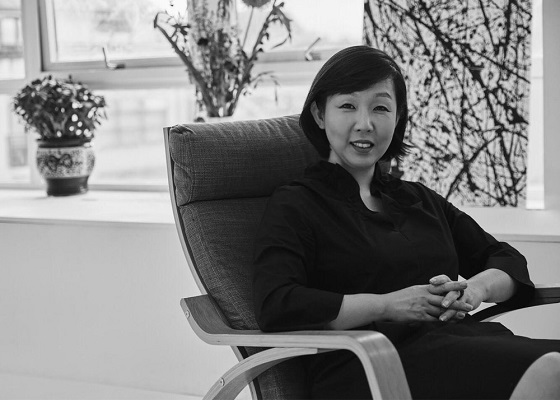

> *The London East Asia Film Festival (LEAFF) is the largest film festival of its kind in London, introducing the diversity of East Asian culture though film. Our world needs, more than ever before, a medium to bridge cultural understanding. There is no better way than through film. LEAFF represents a culmination of the most inspiring, engaging and inclusive cross-cultural programming. LEAFF brings the best of East Asian cinema every year to the capital and aims to champion the growing collaboration in East Asian filmmaking.*

This paper analyses the data collected from the London East Asia Film Festival (LEAFF) 2019. It does so with the intention of providing a summary of how successful the event was, and to provide a benchmark for future editions

# Section 1: Quotes from the Audience

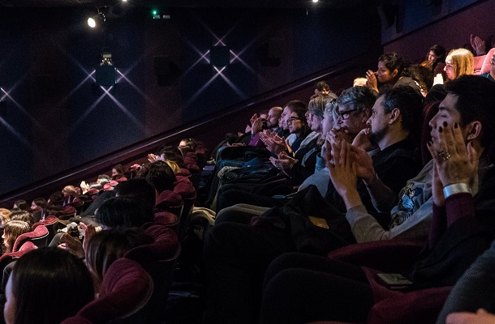

This section presents some of the comments made by audience members who have attended LEAFF 2019.

> *“Very positive, fascinating and varied films; informative discussion, nice atmosphere.”*

> *“Pleasant and welcoming - good for going as a solo customer.”*

> *“A great chance to see films you otherwise would not.”*

> *“A meaningful and memorable experience.”*

> *“Eye-opening; new but at home.”*

> *“Intensive and inspiring”*

> *“Mind-opening”*

# Section 2: Key Performance Metrics

This section presents key analyis of the festival’s performance data.

## Section 2.1: How much did the audience enjoy LEAFF?

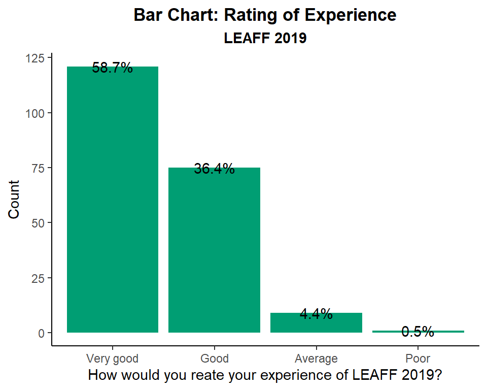

Figure 1

- In **Figure 1**, 95% of attendees rated their LEAFF experience as being **Very good** or **Good**.
- This demonstrates that the majority of attendees enjoyed LEAFF and that the programme and activities which were part of this were successful in capturing the public’s interests and appetite for film and cinema.

## Section 2.2: How likely are the audience to recommend LEAFF to friends and colleagues?

- In the table below, 100% of respondents said they were either **Very likely** or **Likely** to recommend a friend or colleague to attend LEAFF.
- This reinforces the findings made in *Section 2.1* where 95% of respondents said their experience of LEAFF was **Very good** or **Good**.

*Likelihood of audience recommending LEAFF to friends or colleagues*

| Selection | Total | Percent |
| --- | --- | --- |
| Very likely | 141 | 71% |
| Likely | 57 | 29% |
| Unlikely | 0 | 0% |

## Section 2.3: Is LEAFF appealing to minority ethnic groups in London?

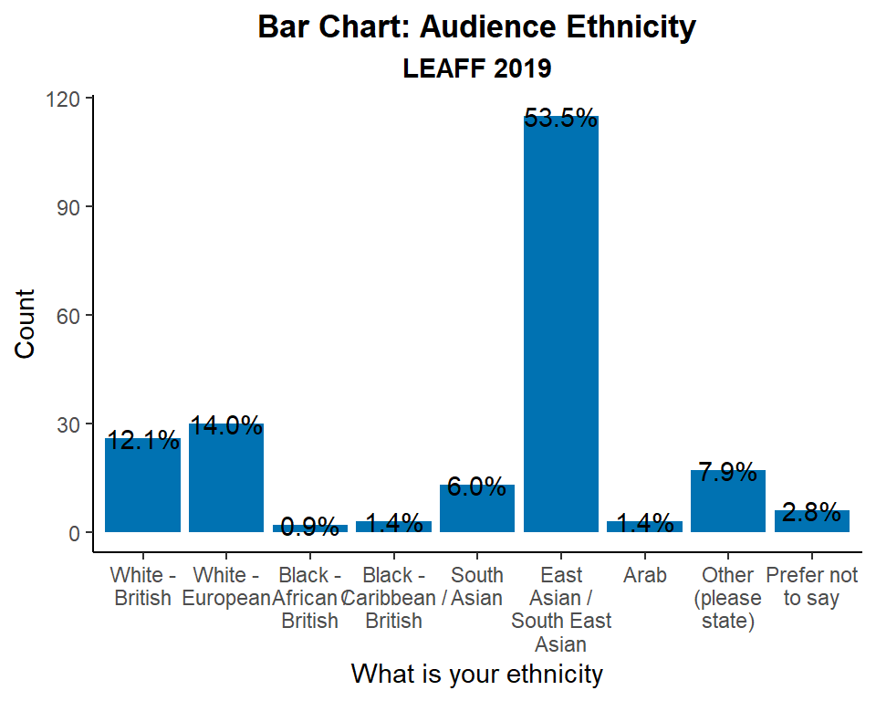

Figure 2

- In **Figure 2**, the majority of the audience who attended LEAFF and completed the survey are of the **East Asian / South East Asian** ethnic group.
- This shows LEAFF is promoting the attendance of ethnic minority groups to watch film.

## Section 2.4: Why does our audience come to LEAFF?

- Digging further into why 95% of survey respondents enjoyed their LEAFF experience to rate it as **Very good** or **Good**, we see the top three reasons for why they wanted to attend LEAFF were *The film (44%), The director(s) and/or actor(s) (14%) and To experience new things (11%)*.
- This demonstrates that LEAFF is more than just a festival that screens films, but it also caters for film fans’ other interests.

## Section 2.5: How many previous and new audiences came to LEAFF?

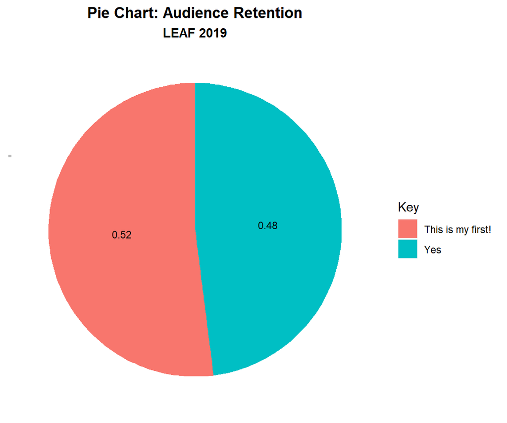

Figure 3

- In **Figure 3**, we have 52% of respondents saying this is their first time coming to the festival.
- Of the remaining 48% of respondents who have returned from previous festivals, we have the following breakdown:
  - Yes - 2015 (13%)
  - Yes - 2016 (19%)
  - Yes - 2017 (27%)
  - Yes - 2018 (42%)
- As a sizeable proportion of attendees have returned to LEAFF from previous years, then this demonstrates that previous LEAFFs were effective in encouraging people to return for this year’s festival.

# Concluding Remarks

[figure not shown]

- From the data analysed in this report, the key findings are:

**Survey respondents enjoyed LEAFF so much that 95% said their experience was *Very good* or *Good*.**

**Survey respondents enjoyed LEAFF so much that 100% of them will recommend a friend or colleague to attend LEAFF.**

**The majority of survey respondents are of the *East Asian / South East Asian* ethnic group.**

**The top three reasons for why survey respondents wanted to attend LEAFF were *The film (44%), The director(s) and/or actor(s) (14%) and To experience new things (11%)*.**

**52% of survey respondents said this is their first time coming to the festival, showing that LEAFF was effective in attracting new audience members and retaining previous members.**